# assignment1

In this analysis, we will determine if there is a correlation between income level and a diagnosis of diabetes.

We will be using the Diabetes Health Indicators Dataset from Kaggle, last updated two years ago.

In this dataset, 0 is for no diabetes or only during pregnancy, 1 is for prediabetes, and 2 is for diabetes. This dataset has a class imbalance.

```python
import numpy as np
from datascience import *

import matplotlib
%matplotlib inline
import matplotlib.pyplot as plt
plt.style.use('fivethirtyeight')
```

```python
# Import dataset as data
data = Table.read_table('diabetes_012_health_indicators_BRFSS2015.csv')

# First five rows
data.show(5)
```

| Diabetes_012 | HighBP | HighChol | CholCheck | BMI | Smoker | Stroke | HeartDiseaseorAttack | PhysActivity | Fruits | Veggies | HvyAlcoholConsump | AnyHealthcare | NoDocbcCost | GenHlth | MentHlth | PhysHlth | DiffWalk | Sex | Age | Education | Income |
| --- | --- | --- | --- | --- | --- | --- | --- | --- | --- | --- | --- | --- | --- | --- | --- | --- | --- | --- | --- | --- | --- |
| 0 | 1 | 1 | 1 | 40 | 1 | 0 | 0 | 0 | 0 | 1 | 0 | 1 | 0 | 5 | 18 | 15 | 1 | 0 | 9 | 4 | 3 |
| 0 | 0 | 0 | 0 | 25 | 1 | 0 | 0 | 1 | 0 | 0 | 0 | 0 | 1 | 3 | 0 | 0 | 0 | 0 | 7 | 6 | 1 |
| 0 | 1 | 1 | 1 | 28 | 0 | 0 | 0 | 0 | 1 | 0 | 0 | 1 | 1 | 5 | 30 | 30 | 1 | 0 | 9 | 4 | 8 |
| 0 | 1 | 0 | 1 | 27 | 0 | 0 | 0 | 1 | 1 | 1 | 0 | 1 | 0 | 2 | 0 | 0 | 0 | 0 | 11 | 3 | 6 |
| 0 | 1 | 1 | 1 | 24 | 0 | 0 | 0 | 1 | 1 | 1 | 0 | 1 | 0 | 2 | 3 | 0 | 0 | 0 | 11 | 5 | 4 |

... (253675 rows omitted)

Let's compare 'Income' with diabetes

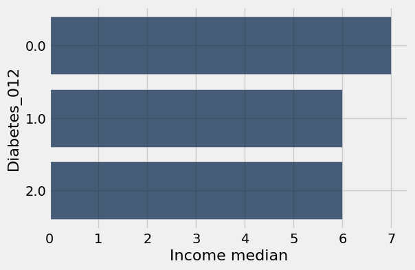

```python
selected = data.select("Income", "Diabetes_012")

selected_group = selected.group("Diabetes_012", collect = np.median)
selected_group.barh("Diabetes_012")
```

As we can see, there is a higher median income level (7) for those without diabetes or only during pregnancy, and a lower median income (6) for both those who are prediabetic and those who have diabetes.

Next, we'll clean the data. We will change the name of our diabetes variable to be more clear and drop unused variables.

```python
# change character variables to dummy variables
data_dummy = data.with_columns('Label Diabetes', data.column('Diabetes_012'))


# drop old variables + weight
data_clean = data_dummy.drop('Diabetes_012','HighBP', 'HighChol', 'CholCheck', 'BMI', 'Smoker', 'Stroke',
                            'HeartDiseaseorAttack', 'PhysActivity', 'Fruits', 'Veggies', 'HvyAlcoholConsump',
                            'AnyHealthcare', 'NoDocbcCost', 'GenHlth', 'MentHlth', 'PhysHlth', 'DiffWalk',
                            'Sex', 'Age', 'Education')

data_clean
```

| Income | Label Diabetes |
| --- | --- |
| 3 | 0 |
| 1 | 0 |
| 8 | 0 |
| 6 | 0 |
| 4 | 0 |
| 8 | 0 |
| 7 | 0 |
| 4 | 0 |
| 1 | 2 |
| 3 | 0 |

... (253670 rows omitted)

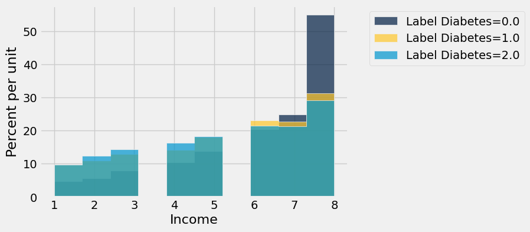

```python
# make histogram
data_clean.hist("Income", group = "Label Diabetes")
```

## Hypothesis test

We can see that by far, the highest proportion of those without diabetes are those with a high income, whereas prediabetic and diabetic people had more of a spread throughout the income groups. We will now do a hypothesis test to see if there is truly a significant correlation between the two variables.

My null hypothesis is that there is no relationship between income and prediabetes/diabetes. My alternative hypothesis is that there is a relationship between income and prediabetes/diabetes.

```python
income_and_diabetes = data_clean.select('Label Diabetes', 'Income')
income_and_diabetes.group('Label Diabetes', collect = np.mean)
```

| Label Diabetes | Income mean |
| --- | --- |
| 0 | 6.20866 |
| 1 | 5.35111 |
| 2 | 5.21009 |

```python
diabetes_by_income = income_and_diabetes.group('Label Diabetes', collect = np.mean)
diabetes_by_income.column('Income mean').item(1) - diabetes_by_income.column('Income mean').item(0)
```

```
-0.8575513545811244
```

```python
def statistic(diabetes_table):
    """
    Arguments:
    diabetes_table, Table: a table that looks like the data table

    Returns:
    a statistic that compares the means of the two groups
    """
    diabetes_by_income = diabetes_table.group("Label Diabetes", collect = np.mean)
    return diabetes_by_income.column("Income mean").item(1) - diabetes_by_income.column("Income mean").item(0)

observed_statistic = statistic(income_and_diabetes)
observed_statistic
```

```
-0.8575513545811244
```

Now let's shuffle our income_and_diabetes table and assign the shuffled table to shuffled_income. We will create a new table called simulated_income that contains the original 'Income' variable and also a shuffled 'Label Diabetes' variable

```python
shuffled_income = income_and_diabetes.sample(income_and_diabetes.num_rows).column('Label Diabetes')
simulated_income = Table().with_columns('Income', income_and_diabetes.column('Income'),
                                        'Label Diabetes', shuffled_income)

simulated_income
```

| Income | Label Diabetes |
| --- | --- |
| 3 | 0 |
| 1 | 2 |
| 8 | 0 |
| 6 | 0 |
| 4 | 0 |
| 8 | 0 |
| 7 | 0 |
| 4 | 0 |
| 1 | 0 |
| 3 | 2 |

... (253670 rows omitted)

Let's calculate the statistic of the simulated table.

```python
statistic(simulated_income)
```

```
-0.008097316475256022
```

Let's test the distribution under the null hypothesis with a function and loop.

```python
def simulation_and_statistic():
    """
    Simulates shuffing the income_and_diabetes table and calculating the statistics.

    Returns one statistic.
    """
    shuffled_income = income_and_diabetes.sample(income_and_diabetes.num_rows).column("Label Diabetes")
    simulated_income = Table().with_columns("Income", income_and_diabetes.column("Income"),
                                        "Label Diabetes", shuffled_income)
    return statistic(simulated_income)

num_repetitions = 100

simulated_statistics = make_array()
for trial in np.arange(num_repetitions):
    simulated_statistics = np.append(simulated_statistics, simulation_and_statistic())
```

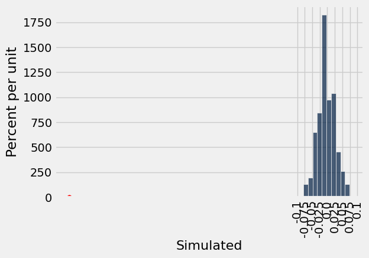

```python
# visualize with a histogram and a red dot representing observed statistic
Table().with_columns("Simulated", simulated_statistics).hist()
plt.scatter(observed_statistic, 0, color='red', s=30);
```

It looks like our observed statistic is not close to most other data points. Let's calculate the probability that we get the observed statistic if the null hypothesis were true.

```python
np.sum(simulated_statistics <= observed_statistic) / num_repetitions
```

```
0.0
```

When compared to an alpha level of 0.05, our conclusion is to reject the null hypothesis. Our p-value is 0, which is less than the alpha level of 0.05, indicating that there is a correlation between income and a diagnosis of diabetes.